# Covid Norte Minas Gerais

Reinaldo Junio Dias de Abreu

19/08/2021

## Análise Covid Norte Minas Gerais

Neste documento realizo a divisão e organização de base de dados sobre Covid19, com ituito primeiramente de analisar o Norte de Minas Gerais.

**BASE DE DADOS UTILIZADAS**

- BASE DE DADOS PRINCIPAL COVID BRASIL: https://www.kaggle.com/unanimad/corona-virus-brazil
- BASE DOS MUNICIPIOS BRASILEIROS: https://github.com/kelvins/Municipios-Brasileiros
- BASE POPULAÇÃO BRASILEIRA: http://blog.mds.gov.br/redesuas/lista-de-municipios-brasileiros/

## Realizando a extração dos dados

### Importando Bibliotecas

```r
library(dplyr, warn.conflicts = FALSE)    # Ref:https://livro.curso-r.com/7-2-dplyr.html
library(ggplot2, warn.conflicts = FALSE)  # Ref:https://livro.curso-r.com/8-1-o-pacote-ggplot2.html
library(lubridate, warn.conflicts = FALSE)
library(forcats, warn.conflicts = FALSE)
library(corrplot, warn.conflicts = FALSE)
```

### Importando Base de Dados

```r
# Definindo diretorio de trabalho
setwd("/home/reinaldo/Documentos/PROJETOIA") # Diretório no Formato Linux

# Dados covid 19
dados = read.csv2(file = "brazil_covid19_cities.csv", sep = ",", dec = ".", header = TRUE)
head(dados)
```

```
##         date state            name   code cases deaths
## 1 2020-03-27    AC      Acrelândia 120001     0      0
## 2 2020-03-27    AC    Assis Brasil 120005     0      0
## 3 2020-03-27    AC       Brasiléia 120010     0      0
## 4 2020-03-27    AC          Bujari 120013     0      0
## 5 2020-03-27    AC        Capixaba 120017     0      0
## 6 2020-03-27    AC Cruzeiro do Sul 120020     0      0
```

```r
# Lista de municipios do Brasil com coordenadas
municipios = read.csv2(file = "municipios.csv", sep = ",", dec = ".", header = TRUE)
head(municipios)
```

```
##   codigo_ibge                nome  latitude longitude capital codigo_uf
## 1     5200050     Abadia de Goiás -16.75730  -49.4412       0        52
## 2     3100104 Abadia dos Dourados -18.48310  -47.3916       0        31
## 3     5200100           Abadiânia -16.19700  -48.7057       0        52
## 4     3100203              Abaeté -19.15510  -45.4444       0        31
## 5     1500107          Abaetetuba  -1.72183  -48.8788       0        15
## 6     2300101             Abaiara  -7.34588  -39.0416       0        23
##   siafi_id ddd      fuso_horario
## 1     1050  62 America/Sao_Paulo
## 2     4001  34 America/Sao_Paulo
## 3     9201  62 America/Sao_Paulo
## 4     4003  37 America/Sao_Paulo
## 5      401  91 America/Sao_Paulo
## 6     1301  88 America/Sao_Paulo
```

```r
# Lista de municipios do Brasil com dados populacionais de 2010
municipios2 = read.csv2(file = "Lista_Municípios_com_IBGE_Brasil_Versao_CSV.csv", sep = ";", dec = ",", header = TRUE)
head(municipios2)
```

```
##              ConcatUF.Mun   IBGE   IBGE7 UF             Munic.pio       Regi.o
## 1 ROAlta Floresta D'oeste 110001 1100015 RO Alta Floresta D�oeste Regi�o Norte
## 2             ROAriquemes 110002 1100023 RO             Ariquemes Regi�o Norte
## 3                ROCabixi 110003 1100031 RO                Cabixi Regi�o Norte
## 4                ROCacoal 110004 1100049 RO                Cacoal Regi�o Norte
## 5            ROCerejeiras 110005 1100056 RO            Cerejeiras Regi�o Norte
## 6     ROColorado do Oeste 110006 1100064 RO     Colorado do Oeste Regi�o Norte
##   Popula..o.2010      Porte
## 1          24392 Pequeno II
## 2          90353      M�dio
## 3           6313  Pequeno I
## 4          78574      M�dio
## 5          17029  Pequeno I
## 6          18591  Pequeno I
```

```r
# Lista de municipios do Norte de Minas Gerais
municipios_norte = read.csv2(file = "cidades_norte_minas.csv", sep = ",", dec = ".", header = TRUE)
head(municipios_norte)
```

```
##     cidades_norte
## 1 Bonito de Minas
## 2  Chapada Gaúcha
## 3  Cônego Marinho
## 4 Icaraí de Minas
## 5      Itacarambi
## 6        Januária
```

### Separando dados de interesse

```r
# Filtrando pelas cidades de Minas Gerais
df = dados %>% filter(state == "MG")
rm(dados) # Removendo da memoria

# Unindo dados dos municipios
municipios = merge(municipios, municipios2, by.x = 'codigo_ibge', by.y = 'IBGE7' )
municipios = municipios %>% select(codigo_ibge, nome, latitude, longitude, Popula..o.2010, Porte)

# Filtrando municipios somente com as cidades do Norte de Minas
cidades = merge(municipios, municipios_norte, by.x = 'nome', by.y = 'cidades_norte', all.y = TRUE)
cidades = cidades %>% select(codigo_ibge, nome, latitude, longitude, Popula..o.2010, Porte)

# Unindo os dados das cidades com dados de COVID
df2 = merge(df, cidades, by.x = 'name', by.y = 'nome', all.y = TRUE)
df2 = df2 %>% select(codigo_ibge, name, codigo_ibge, latitude, longitude, Popula..o.2010, Porte, date, cases, deaths)
head(df2)
```

```
##   codigo_ibge            name latitude longitude Popula..o.2010     Porte
## 1     3101003 Águas Vermelhas -15.7431  -41.4571          12722 Pequeno I
## 2     3101003 Águas Vermelhas -15.7431  -41.4571          12722 Pequeno I
## 3     3101003 Águas Vermelhas -15.7431  -41.4571          12722 Pequeno I
## 4     3101003 Águas Vermelhas -15.7431  -41.4571          12722 Pequeno I
## 5     3101003 Águas Vermelhas -15.7431  -41.4571          12722 Pequeno I
## 6     3101003 Águas Vermelhas -15.7431  -41.4571          12722 Pequeno I
##         date cases deaths
## 1 2020-07-03    21      0
## 2 2020-06-28    19      0
## 3 2020-10-10    73      0
## 4 2020-08-13    29      0
## 5 2020-08-16    29      0
## 6 2021-02-27   256      3
```

### Armazenando em novo arquivo e liberando memória

```r
write.csv2(df2, file="covid_norte_minas.csv", row.names = FALSE)
rm(cidades, df, df2, municipios, municipios2, municipios_norte)
```

## Analisando base de dados gerada

```r
dados = read.csv2(file = "covid_norte_minas.csv", sep = ";", dec = ",", header = TRUE)
names(dados)
```

```
## [1] "codigo_ibge"    "name"           "latitude"       "longitude"
## [5] "Popula..o.2010" "Porte"          "date"           "cases"
## [9] "deaths"
```

### Adaptando formato de data (dia/mes/ano)

```r
dados[,'dia'] = day(as.Date(dados[,'date'], format = "%Y-%m-%d"))
dados[,'mes'] = month(as.Date(dados[,'date'], format = "%Y-%m-%d"))
dados[,'ano'] = year(as.Date(dados[,'date'], format = "%Y-%m-%d"))

dados = dados %>% select(codigo_ibge, name, codigo_ibge, latitude, longitude, Popula..o.2010, Porte, dia, mes, ano, cases, deaths)

# Removendo linhas sem amostragem
dados = na.omit(dados)
```

### Dividindo dados por ano

```r
df2020 = dados %>% filter(ano == '2020')
df2021 = dados %>% filter(ano == '2021')
```

## Processando dados de 2020

### Segregacao em dataframes mensais em uma lista de dataframes

```r
data = df2020

dados <- list()
for(i in 1:12){
  b = data %>% filter(mes == i)
  b = arrange(b, name, dia, mes, ano)
  dados[i] <- list(b)
}
```

### Adicionando Indices por mil de óbitos e casos

```r
for(i in 3:12){
  t1 = dados[[i]]
  t2 = t1 %>% group_by(name) %>% summarise(
    porte = first(Porte),
    latitude = max(latitude),
    longitude = max(longitude),
    populacao =  max(Popula..o.2010),
    totcasos = max(cases),
    totobitos = max(deaths)
  )
  t2 = t2 %>% mutate(
    indobito = (totobitos / populacao)*1000,
    indcasos = (totcasos / populacao)*1000
  ) %>% select( name, porte, latitude, longitude, populacao,
                totcasos, indcasos, totobitos, indobito)
  dados[[i]] = t2
  #write.csv2(t2, file = paste("casos_covid_mes_", i,".csv", sep=""), row.names = FALSE)
}
```

## Escolhendo base de dados mensal

Para essa apresentação inicial, vou analisar primeiramente o mês **Dezembro/2020**, poís como o total de casos e óbitos da base de dados são acumulados, podemos com esse mês visualizar o cenário de Covid19 no Norte de Minas Gerais do ano de 2020.

### Separando dados do mês 12/2020

```r
df = dados[[12]] # Separando o dataframe de 2020 referente ao mês de Dez/2020
head(df)
```

```
## # A tibble: 6 × 9
##   name   porte latitude longitude populacao totcasos indcasos totobitos indobito
##   <fct>  <fct>    <dbl>     <dbl>     <int>    <int>    <dbl>     <int>    <dbl>
## 1 Águas… Pequ…    -15.7     -41.5     12722      134   10.5           1   0.0786
## 2 Beriz… Pequ…    -15.6     -41.7      4370       22    5.03          0   0
## 3 Bocai… Pequ…    -17.1     -43.8     46654      609   13.1           8   0.171
## 4 Bonit… Pequ…    -15.3     -44.8      9673        6    0.620         0   0
## 5 Botum… Pequ…    -16.9     -43.0      6497       11    1.69          0   0
## 6 Brasí… Pequ…    -16.2     -44.4     31213      338   10.8           5   0.160
```

### Municípios com maior população

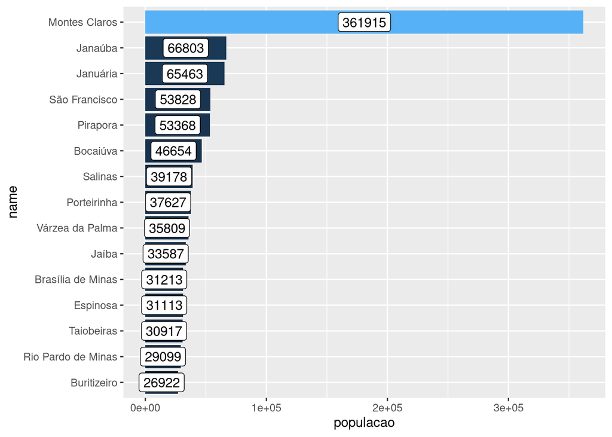

```r
df %>%
  top_n(15, populacao) %>%
  mutate(name = forcats::fct_reorder(name, populacao)) %>%
  ggplot() +
  geom_col(aes(x = name, y = populacao, fill = populacao), show.legend = FALSE) +
  geom_label(aes(x = name, y = populacao/2, label = populacao)) +
  coord_flip()
```

### Municípios com mais casos

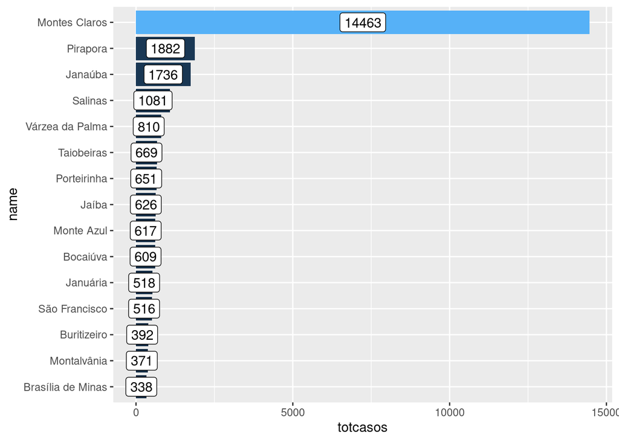

```r
df %>%
  top_n(15, totcasos) %>%
  mutate(name = forcats::fct_reorder(name, totcasos)) %>%
  ggplot() +
  geom_col(aes(x = name, y = totcasos, fill = totcasos), show.legend = FALSE) +
  geom_label(aes(x = name, y = totcasos/2, label = totcasos)) +
  coord_flip()
```

### Municípios com mais obitos

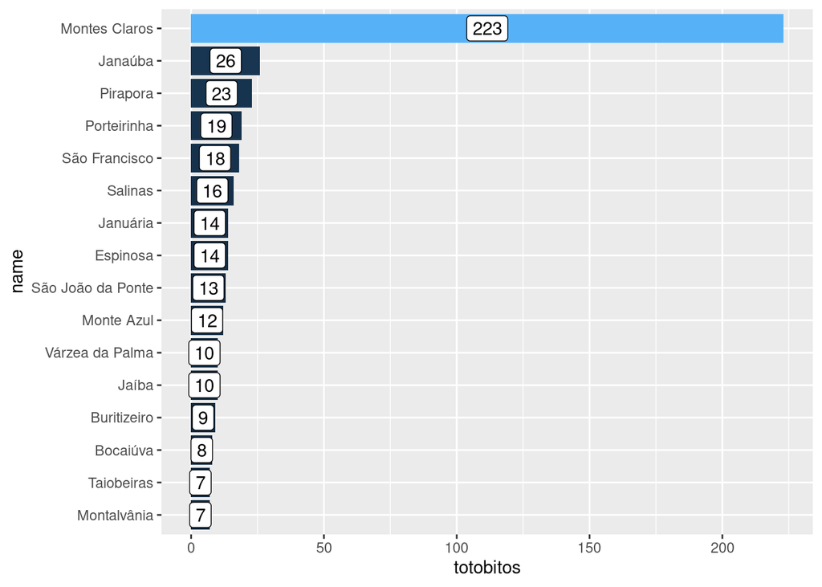

```r
df %>%
  top_n(15, totobitos) %>%
  mutate(name = forcats::fct_reorder(name, totobitos)) %>%
  ggplot() +
  geom_col(aes(x = name, y = totobitos, fill = totobitos), show.legend = FALSE) +
  geom_label(aes(x = name, y = totobitos/2, label = totobitos)) +
  coord_flip()
```

### Índice de casos

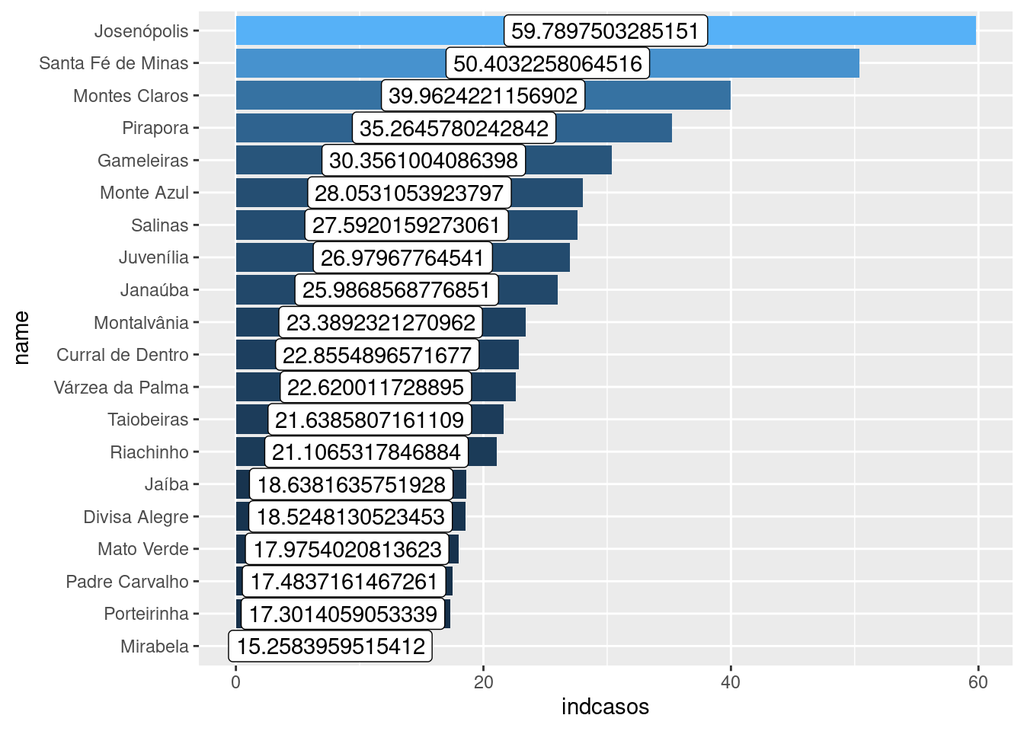

```r
# Quanto maior o indice, indica que há muitos casos em relação a populacao
# Quanto menor o indice, indica que há poucos casos em relação a populacao
df %>%
  top_n(20, indcasos) %>%
  mutate(name = forcats::fct_reorder(name, indcasos, .desc = FALSE)) %>%
  ggplot() +
  geom_col(aes(x = name, y = indcasos, fill = indcasos), show.legend = FALSE) +
  geom_label(aes(x = name, y = indcasos/2, label = indcasos)) +
  coord_flip()
```

#### Visualização dos maiores índices de caso em tabela

```r
arrange(df, desc(indcasos)) %>% top_n(20, indcasos) %>% select(name, porte, populacao, totcasos, indcasos)
```

```
## # A tibble: 20 × 5
##    name              porte      populacao totcasos indcasos
##    <fct>             <fct>          <int>    <int>    <dbl>
##  1 Josenópolis       Pequeno I       4566      273     59.8
##  2 Santa Fé de Minas Pequeno I       3968      200     50.4
##  3 Montes Claros     Grande        361915    14463     40.0
##  4 Pirapora          M�dio          53368     1882     35.3
##  5 Gameleiras        Pequeno I       5139      156     30.4
##  6 Monte Azul        Pequeno II     21994      617     28.1
##  7 Salinas           Pequeno II     39178     1081     27.6
##  8 Juvenília         Pequeno I       5708      154     27.0
##  9 Janaúba           M�dio          66803     1736     26.0
## 10 Montalvânia       Pequeno I      15862      371     23.4
## 11 Curral de Dentro  Pequeno I       6913      158     22.9
## 12 Várzea da Palma   Pequeno II     35809      810     22.6
## 13 Taiobeiras        Pequeno II     30917      669     21.6
## 14 Riachinho         Pequeno I       8007      169     21.1
## 15 Jaíba             Pequeno II     33587      626     18.6
## 16 Divisa Alegre     Pequeno I       5884      109     18.5
## 17 Mato Verde        Pequeno I      12684      228     18.0
## 18 Padre Carvalho    Pequeno I       5834      102     17.5
## 19 Porteirinha       Pequeno II     37627      651     17.3
## 20 Mirabela          Pequeno I      13042      199     15.3
```

### Índice de óbitos

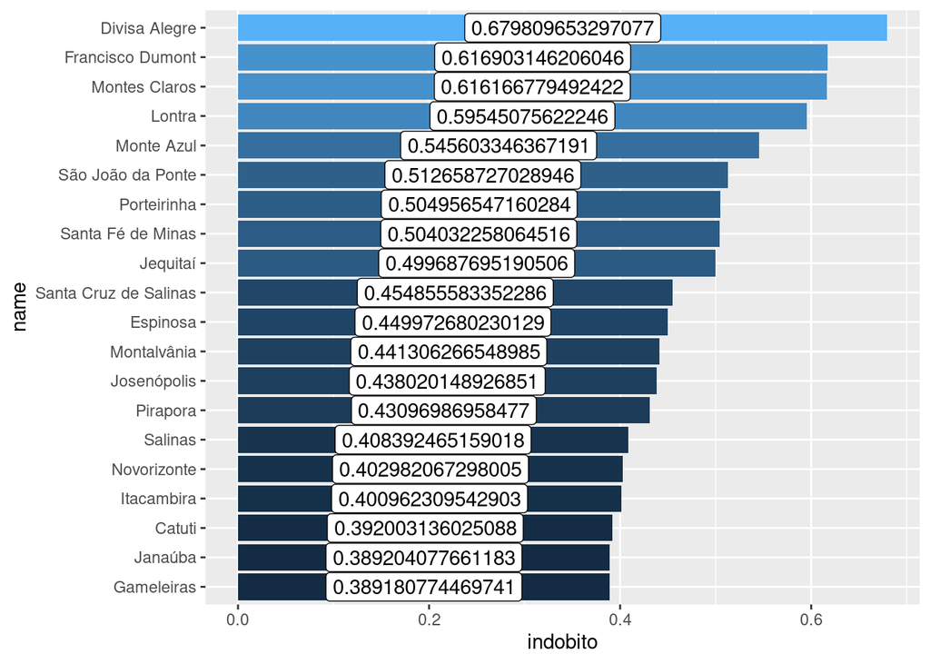

```r
# Quanto maior o indice, indica que há muitos obitos em relação a populacao
# Quanto menor o indice, indica que há poucos obitos em relação a populacao
df %>%
  top_n(20, indobito) %>%
  mutate(name = forcats::fct_reorder(name, indobito, .desc = FALSE)) %>%
  ggplot() +
  geom_col(aes(x = name, y = indobito, fill = indobito), show.legend = FALSE) +
  geom_label(aes(x = name, y = indobito/2, label = indobito)) +
  coord_flip()
```

```r
arrange(df, desc(indobito)) %>% top_n(20, indobito) %>% select(name, porte, populacao, totobitos, indobito)
```

```
## # A tibble: 20 × 5
##    name                  porte      populacao totobitos indobito
##    <fct>                 <fct>          <int>     <int>    <dbl>
##  1 Divisa Alegre         Pequeno I       5884         4    0.680
##  2 Francisco Dumont      Pequeno I       4863         3    0.617
##  3 Montes Claros         Grande        361915       223    0.616
##  4 Lontra                Pequeno I       8397         5    0.595
##  5 Monte Azul            Pequeno II     21994        12    0.546
##  6 São João da Ponte     Pequeno II     25358        13    0.513
##  7 Porteirinha           Pequeno II     37627        19    0.505
##  8 Santa Fé de Minas     Pequeno I       3968         2    0.504
##  9 Jequitaí              Pequeno I       8005         4    0.500
## 10 Santa Cruz de Salinas Pequeno I       4397         2    0.455
## 11 Espinosa              Pequeno II     31113        14    0.450
## 12 Montalvânia           Pequeno I      15862         7    0.441
## 13 Josenópolis           Pequeno I       4566         2    0.438
## 14 Pirapora              M�dio          53368        23    0.431
## 15 Salinas               Pequeno II     39178        16    0.408
## 16 Novorizonte           Pequeno I       4963         2    0.403
## 17 Itacambira            Pequeno I       4988         2    0.401
## 18 Catuti                Pequeno I       5102         2    0.392
## 19 Janaúba               M�dio          66803        26    0.389
## 20 Gameleiras            Pequeno I       5139         2    0.389
```

### Descrição dos dados

```r
summary(df)
```

```
##                 name           porte       latitude        longitude
##  Águas Vermelhas  : 1   Grande    : 1   Min.   :-17.89   Min.   :-45.99
##  Berizal          : 1   M�dio     : 3   1st Qu.:-16.58   1st Qu.:-44.41
##  Bocaiúva         : 1   Pequeno I :70   Median :-16.00   Median :-43.83
##  Bonito de Minas  : 1   Pequeno II:14   Mean   :-15.72   Mean   :-43.58
##  Botumirim        : 1                   3rd Qu.:-15.39   3rd Qu.:-42.86
##  Brasília de Minas: 1                   Max.   : -6.44   Max.   :-36.89
##  (Other)          :82
##    populacao         totcasos          indcasos         totobitos
##  Min.   :  2962   Min.   :    5.0   Min.   : 0.6203   Min.   :  0.000
##  1st Qu.:  5747   1st Qu.:   39.5   1st Qu.: 6.2896   1st Qu.:  1.000
##  Median :  8006   Median :   87.0   Median : 9.6581   Median :  2.000
##  Mean   : 18240   Mean   :  367.2   Mean   :12.4000   Mean   :  6.273
##  3rd Qu.: 18069   3rd Qu.:  229.2   3rd Qu.:14.6049   3rd Qu.:  5.000
##  Max.   :361915   Max.   :14463.0   Max.   :59.7897   Max.   :223.000
##
##     indobito
##  Min.   :0.00000
##  1st Qu.:0.08555
##  Median :0.20005
##  Mean   :0.22599
##  3rd Qu.:0.34471
##  Max.   :0.67981
##
```

### Análise Gráfica

#### Boxplot relacionando o porte da cidade ao índice de casos

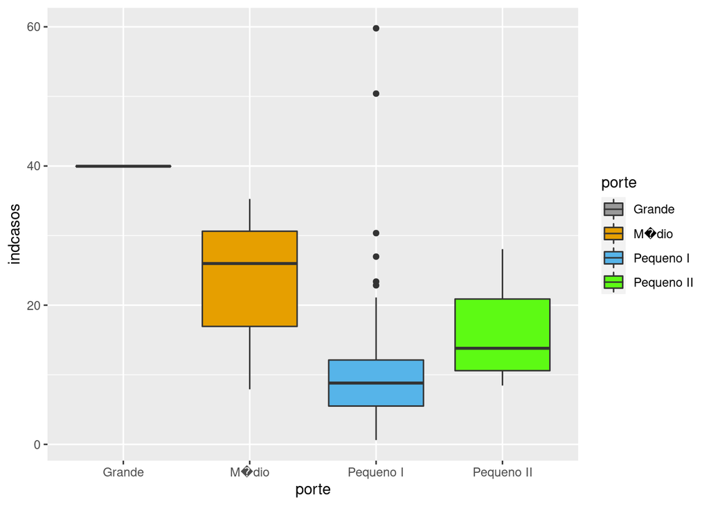

```r
p = df %>% ggplot() + geom_boxplot(aes(x=porte, y=indcasos, fill = porte) )
p + scale_fill_manual(values=c("#999999", "#E69F00", "#56B4E9","#5dfa14"))
```

#### Boxplot relacionando o porte da cidade ao índice de óbitos

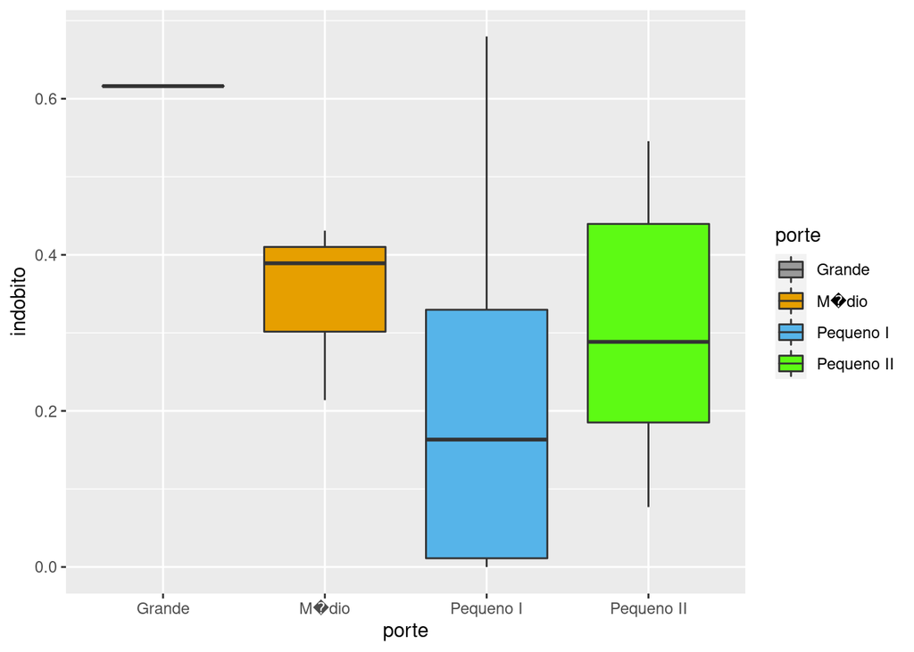

```r
p = df %>% ggplot() + geom_boxplot(aes(x=porte, y=indobito, fill = porte) )
p + scale_fill_manual(values=c("#999999", "#E69F00", "#56B4E9","#5dfa14"))
```

### Teste de Normalidade e Correlação

#### Dispersão dos dados

Podemos visualizar uma correlação, onde quanto maior o indice de casos há também um crecimento do número de óbitos, mas não tão significativa.

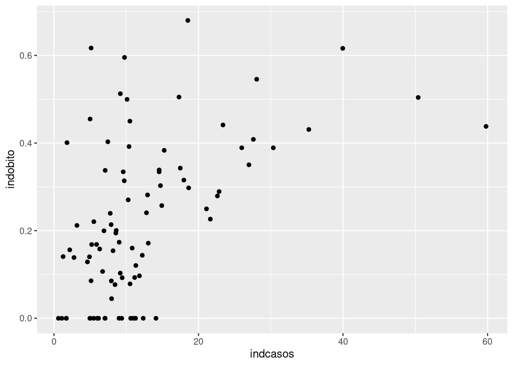

```r
ggplot(df) +
  geom_point(mapping = aes(x = indcasos, y = indobito))
```

#### Correlação

Podemos visualizar uma alta correlação entre a população (CENSO 2010) com o número de casos e óbitos. Podemos ver também, uma pequena correlação de **52%** entre os índices criados.

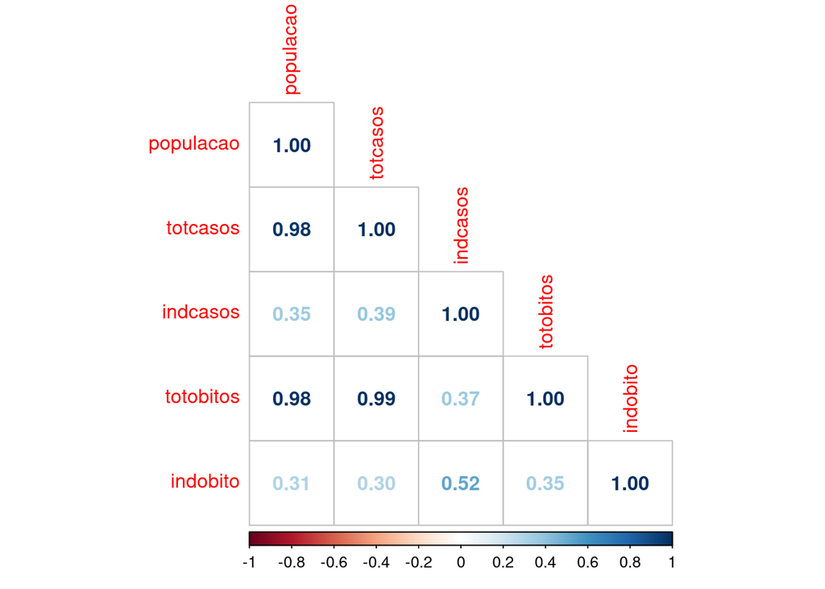

```r
correlacao = stats::cor(x = df[,5:9])
corrplot(correlacao, method = 'number', type = 'lower')
```

#### Teste de Normalidade dos Índices

Ambos os índices possuem valores de p-value utilizando o teste Shapiro-Wilk abaixo de 5%. Mostrando que os dados não estão normalmente distribuídos, algo que podemos visualizar graficamente abaixo com o histograma.

```r
shapiro.test(df$indcasos)
```

```
##
##  Shapiro-Wilk normality test
##
## data:  df$indcasos
## W = 0.79048, p-value = 7.45e-10
```

```r
shapiro.test(df$indobito)
```

```
##
##  Shapiro-Wilk normality test
##
## data:  df$indobito
## W = 0.93894, p-value = 0.0004351
```

#### Histogramas dos Índices

##### Índice de Casos

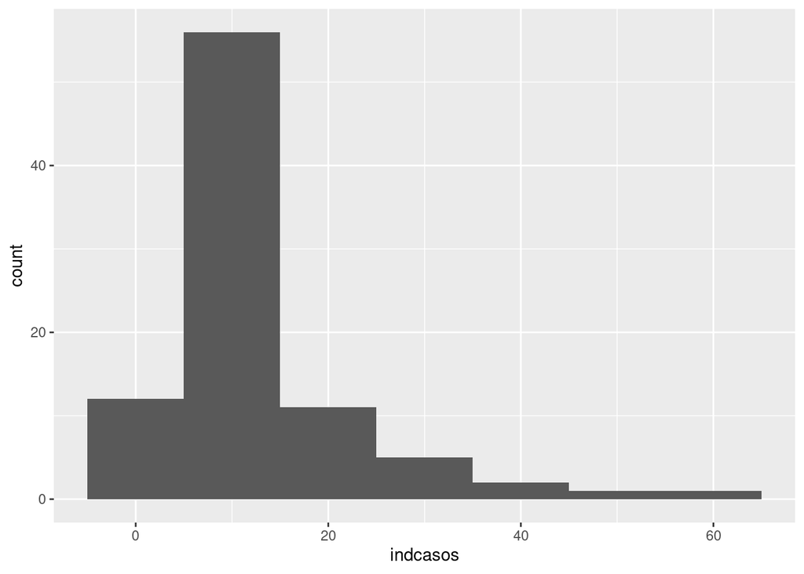

```r
ggplot(data = df, aes(x = indcasos)) +
  geom_histogram(binwidth = 10)
```

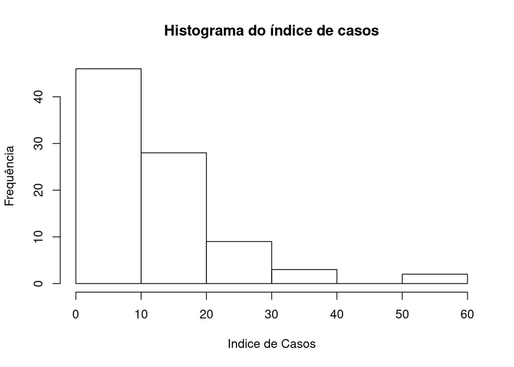

```r
hist(df$indcasos, xlab = "Indice de Casos", ylab = "Frequência", main = "Histograma do índice de casos")
```

##### Índice de Óbitos

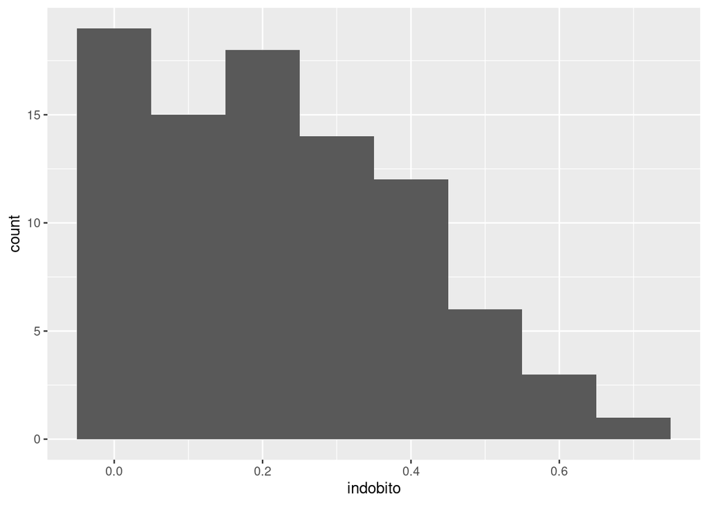

```r
ggplot(data = df, aes(x = indobito)) +
  geom_histogram(binwidth = 0.1)
```

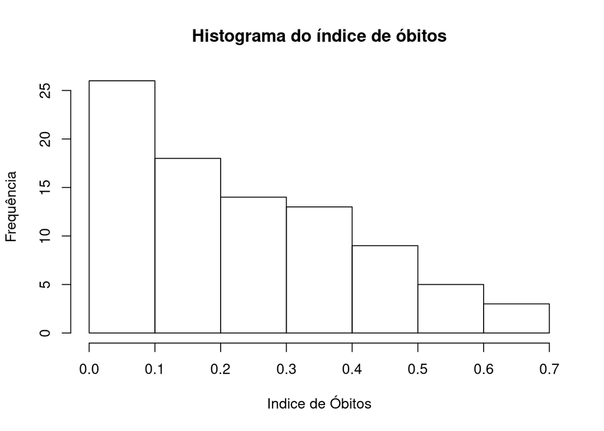

```r
hist(df$indobito, xlab = "Indice de Óbitos", ylab = "Frequência", main = "Histograma do índice de óbitos")
```